# Laboratorio 7

Integrantes:

```
- Francis Aguilar - 22243
- Diego García - 22404
- Angela García -22869
```

enlace al repositorio: https://github.com/angelargd8/lab7-modsim

# Teoría

## Parte 1

**1. Describa con sus propias palabras la diferencia fundamental entre una Entidad de DES y un Agente de MBA. ¿Por qué esta diferencia hace que cada paradigma sea adecuado para tipos de problemas distintos? Proporcione un ejemplo de un problema de modelado para cada uno**

La diferencia entre una entidad en DES es que está es pasiva y sigue un flujo de procesos controlado por eventos del sistema, mientras que un MBA es autónomo, toma decisiones y puede interactuar con otros agentes de forma independiente. Y en DES, la importancia está en la secuencia temporal de eventos y eficiencia de los procesos, un ejemplo puede ser una línea de producción o un sistema de colas. Mientras que en AMB se estudian comportamientos emergentes a partir de las interacciones individuales, un ejemplo es la propagación de una epidemia o el tráfico peatonal. DES es ideal para sistemas estructurados y predecibles, mientras que MBA es para sistemas complejos, adaptativos y descentralizados.

**2. Explique por qué las colas son una consecuencia inevitable en la mayoría de los sistemas modelados con DES. ¿Qué tipo de información valiosa podemos extraer al analizar la longitud de una cola y el tiempo de espera en ella a lo largo de una simulación?**

Las colas son una consecuencia inevitable en la mayoría de los sistemas modelados con DES porque los recursos disponibles para atender las entidades suelen ser limitados, mientras que las llegadas y los tiempos de servicio pueden variar de una forma impredecible. Cuando la demanda llega a superar la capacidad del sistema, las entidades deben de esperar, haciendo una cola. Y al analizar la longitud de la cola y el tiempo de espera promedio, esto permite evaluar el desempeño del sistema, identificando los cuellos de botella y medir la eficiencia en la atención. Está información es importante para lograr tomar decisiones de mejora, como ajustar la cantidad de servidores, optimizar procesos o equilibrar la carga de trabajo. De esta manera, buscando reducir los tiempos de espera y aumentar la satisfacción de los usuarios.

**3. En clase se mencionaron los recursos móviles, estáticos y portátiles. Describa un escenario (diferente al hospital) que involucre los tres tipos de recursos. Identifique qué elementos serían cada tipo de recurso y cómo interactuarían.**

Un escenario podría ser un aeropuerto, los recursos móviles serían los vehivulos de traslado interno, como autobuses o tractores de equipaje que se van moviendo entra las terminales y pistas. Los recursos estáticos podrían ser las puertas de embarque y las bandas de equipaje que tienen una ubicación fija y sirven como puntos donde las entidades reciben un servicio específico. Y los recursos portátiles podrían ser los escaners de seguridad y los radios de comunicación usados por el personal, que no se mueven solos, sino que son transportados y usados por los agentes humanos para cumplir sus tareas. Estos recursos interactúan de forma coordinada, porque los pasajeros pasan por estaciones estáticas como los puntos de control y estos son atendodas por los trabajadores que usan equipos portátiles.Finalmente son transportados en vehículos móviles hacia su avión, mostrando como la gestión eficiente de los tres tipos de recursos es importante para el fluejo continuo del sistema.

**4. Imagine que está modelando la propagación de una enfermedad en una ciudad (un problema clásico de MBA). Ahora, quieres añadir el proceso de vacunación en centros de salud. ¿Cómo podría combinar MBA y DES? ¿Qué parte del modelo sería MBA y cuál DES? ¿Qué información pasaría de un modelo a otro?**

En un modelo de propagación de enfermedad de una ciudad, el MBA seria ideal para poder representar los individuos de la población ya que cada agente puede tener coportamientos y estados propios e interactual con otros agentes de manera autónoma, determinando así la dinámica de contagio. Por otro lado, DES se usaría para modelar el proceso de vacunación en los centros de salud, donde las personas llegan, esperan en una cola, son atendidas por un recurso como el personal médico y luego se retiran. Entonces, la información que se intercambiaria entre ambos modelos llegaría a ser bidireccional, desde el MBA al DES se transferiría el flujo de agentes que deciden asistir a vacunarse, mostrando la demanda en los centros de salud. Y de DES hacia AMB, el resultado del proceso, qué agentes fueron vacunados y en qué momento, se incorporaría al estado de los individuos dentro del modelo basado en agentes. De esta forma, los dos enfoques se complementan, ya que el AMB captura la interacción social y el comportamiento individual, mientras que el DES representa la manera de la logística y eficiencia del proceso de vacunación.

## Parte 2

**1. Imagine que usted ha sido contratado para modelar el sistema de tráfico de una gran ciudad con el fin de evaluar el impacto de un nuevo sistema de metro. ¿Por qué un modelo puramente MBA, DES o DS sería, por sí solo, insuficiente para esta tarea? Describa cómo diseñaría usted un modelo híbrido para este problema, identificando qué componente del sistema sería modelado con cada paradigma y cómo interactuarían entre sí.**

Si solo fuera un modelo MBA, DES o DS, sería insuficiente para evaluar el impacto de un nuevo sistema de metro porque cada paradigma captura solo una parte del problema. EL MBA representaría bien el comportamiento individual de los conductores y pasajeros, pero no los procesos operativos del metro ni las dinámicas del tráfico. Mientras, el DES modela con presición los flujos, colas y operaciones del transporte público, pero no logra explicar como es que cambian las decisiones individuales. Y el DS describe las tendencias agregadas del sistema, pero sin detalle espacial ni individual. Por eso, debería de usarse un modelo híbrido donde el MBA represente viajeros y sus decisiones de movilidad, el DES modele las operaciones del metro, buses y semáforos y el DS describa la evolución global de la demanda y la congestión en el tiempo. Y los tres interactuarían compartiendo la información, el MBA generando flujos de pasajeros hacia el DES, este devolvería tiempos y nivoeles de servicion que actualizarían las decisiones de los agentes y el DS ajustaría las tendencias agregadas de uso del transporte según los resultados observados.

**2. En el "Patrón 1: MBA → DES", la transición de un agente a una entidad debe ser fluida. Describa a nivel conceptual y técnico (¿qué información específica se debe transferir?) cómo se realizaría esta transición en una herramienta como AnyLogic, o de forma más abstracta, en un marco de trabajo en Python que combinara las bibliotecas Mesa (para MBA) y SimPy (para DES).**

En el "Patrón 1: MBA → DES", la transición fluida entre un agente y una entidad implica que al cambiar de MBA a DES, el agente mantenga su identidad y estado relevante. El agente, por ejemplo como una persona que decide ir a un centro de vacunacion se convierte temporalmente en una entidad del sistema de colas del DES para representar su paso por el proceso de servicio. Y herramientas como AnyLogic, implica transferir atributos clave del agente, como la hora de llegada, prioridad, ubicación o estado de salud al objetivo de entidad del bloque DES, para luego devolver los resultados al agente original al terminar el proceso. Y en un marco híbrido Mesa-Simpy, la integración lograría pasando un diccionario o estructura de datos con las propiedades del agente al proceso Simpy que simula la cola o servicio, permitiendo que al completar el evento Simpy decuelca la información actualizada, como la duración éxito o cambio de estado al modelo Mesa, así manteniendo la coherencia de los dos paradigmas.

**3. El "Patrón 3: DS dentro de un Agente" es un claro ejemplo de modelado multi-escala. Proponga usted otro escenario (fuera del ámbito biológico), por ejemplo, en economía o sociología, donde este patrón sería de gran utilidad. ¿Qué representaría el agente (MBA) y qué dinámica capturaría su modelo de Dinámica de Sistemas (DS) interno?**

Otro escenario, pordría ser en la modelación del comportamiento de empresas dentro de un mercado financiero. Un agente del modelo MBA, representaría una empresa individual que toma decisiones estratégicas, como invertit, producir o ajustar precios, en función de su entorno competitivo. Dentro de cada empresa, un modelo DS capturaría las dinámicas continuas de sus variables internas como flujo de caja, inventario, inversión en innovación o nivel de endeudamiento, a través de tasas y retroalimentaciones. Entonces, así mientra slos agentes interactúan en el mercado competencia, cooperación o en variaciones de demanda, cada uno va evolucionando internamente según sus propias dinámicas financiera y operativas. Y este enfoque que es multi-escala permite analizar como decisiones infividuales y procesos internos combinan para generar patrones emergentes como crisis económicas, formación de monopolios o ciclos de expansión y recesión.

**4. La combinación de paradigmas de modelado presenta desafíos significativos. Desde su perspectiva, ¿cuáles cree usted que son los dos mayores desafíos al construir y validar un modelo híbrido? Considere aspectos como la calibración de parámetros entre los diferentes componentes, la complejidad del software y la validación de los resultados emergentes.**

Los mayores desafíos al contruir y validar un modelo híbrido es la calibración y coherencia entre paradignmas, ya qeu cada componente, AMB, DES, DS, opera ocn escalas temporales a niveles de detalle y unidades distintas. Alinear parámetros, como tasas, probabilidades, tiempos o retroalimentaciones para que representen la misma realidad sin generar algun tipo de inconsistencias requiren datos precisos y un proceso iterativo de ajuste. Y el otro desafío es la validación de los resultados emergentes, pues los comportamientos globales del sistema no siempre pueden contrastar directamente con datos reales o expectativas teóricas, y más cuando suegen de la interacción entre componentes heterogéneos. Además, la complejidad computacional aumenta al integrar distintos marcos o motores de simulación, lo que hace que se difícil darle seguimiento de errores y la reproducibilidad. Y todos esas difícultades hacen que la creación de los modelos híbridos requieran de un equilibrio que sea realista, simple y trazable de los resultados.

# Práctica

## Parte 1

Debe construir una simulación de eventos discretos para una clínica simple usando la biblioteca SimPy. El objetivo es modelar un flujo de pacientes de dos etapas (registro y consulta) para analizar el rendimiento del sistema, identificar cuellos de botella y proponer mejoras basadas en datos. El escenario es una clínica tiene un flujo de pacientes que consta de dos pasos secuenciales:

1. Registro: Al llegar, cada paciente debe ser registrado por un recepcionista.
2. Consulta: Después del registro, el paciente es atendido por un médico.

```python
import simpy
import random
import statistics

NUM_RECEPCIONISTAS = 1
NUM_MEDICOS = 2
TIEMPO_REGISTRO_PROMEDIO = 2
TIEMPO_CONSULTA_PROMEDIO = 7
# Parámetros de simulación
TASA_LLEGADA_PACIENTES = 1/4  # en promedio, 1 paciente cada 4 minutos
TIEMPO_SIMULACION = 120  # simular 2 horas (120 minutos)

tiempos_de_espera_totales = []

def paciente(env, nombre, recepcionistas, medicos):
    # Tiempo de llegada del paciente
    tiempo_llegada = env.now

    # Proceso de registro
    print(f'{nombre} llega a recepción en tiempo {env.now:.2f}')
    with recepcionistas.request() as req_recepcion:
        yield req_recepcion
        print(f'{nombre} comienza registro en tiempo {env.now:.2f}')
        # servicio de registro estocástico (exponencial)
        tiempo_registro = random.expovariate(1.0 / TIEMPO_REGISTRO_PROMEDIO)
        yield env.timeout(tiempo_registro)
        print(f'{nombre} termina registro en tiempo {env.now:.2f}')

    # Proceso de consulta médica
    print(f'{nombre} espera consulta en tiempo {env.now:.2f}')
    with medicos.request() as req_medico:
        yield req_medico
        print(f'{nombre} comienza consulta en tiempo {env.now:.2f}')
        # servicio de consulta estocástico (normal aproximado)
        tiempo_consulta = max(0.1, random.normalvariate(TIEMPO_CONSULTA_PROMEDIO, 2))
        yield env.timeout(tiempo_consulta)
        print(f'{nombre} termina consulta en tiempo {env.now:.2f}')

    # Calcula y registra el tiempo total en el sistema
    tiempo_total = env.now - tiempo_llegada
    tiempos_de_espera_totales.append(tiempo_total)
    print(f'{nombre} completó su visita. Tiempo total: {tiempo_total:.2f} minutos')
```

```python
def generador_pacientes(env, recepcionistas, medicos, tasa_llegada=TASA_LLEGADA_PACIENTES):

    i = 0
    while True:
        # tiempo hasta la siguiente llegada (Poisson/exponencial)
        if tasa_llegada <= 0:
            # si la tasa no está definida, evita división por cero: pausa infinita
            # (el llamador debe establecer una tasa positiva antes de ejecutar)
            yield env.timeout(float('inf'))
        intervalo = random.expovariate(tasa_llegada)
        yield env.timeout(intervalo)
        i += 1
        nombre = f'Paciente {i}'
        env.process(paciente(env, nombre, recepcionistas, medicos))
```

```python
def simulacion():

    # Inicializar ambiente y recursos
    env = simpy.Environment()
    recepcionistas = simpy.Resource(env, capacity=NUM_RECEPCIONISTAS)
    medicos = simpy.Resource(env, capacity=NUM_MEDICOS)

    # Iniciar el generador de pacientes
    env.process(generador_pacientes(env, recepcionistas, medicos, TASA_LLEGADA_PACIENTES))

    # Ejecutar la simulación
    print("\nIniciando simulación...")
    env.run(until=TIEMPO_SIMULACION)

    # Análisis de resultados
    print("\nAnálisis de Resultados:")
    print(f"Total de pacientes atendidos: {len(tiempos_de_espera_totales)}")
    print(f"Tiempo promedio en clínica: {statistics.mean(tiempos_de_espera_totales):.2f} minutos")
    print(f"Tiempo máximo en clínica: {max(tiempos_de_espera_totales):.2f} minutos")
    print(f"Tiempo mínimo en clínica: {min(tiempos_de_espera_totales):.2f} minutos")
    print(f"Desviación estándar: {statistics.stdev(tiempos_de_espera_totales):.2f} minutos")
```

## Preguntas de análisis

Una vez que su script esté completamente funcional, le corresponderá utilizarlo como un laboratorio virtual para investigar y responder a las siguientes preguntas. Para cada interrogante, es fundamental que modifique los parámetros de entrada, ejecute la simulación correspondiente y utilice los resultados numéricos obtenidos para fundamentar rigurosamente sus conclusiones.

1. **Configure la simulación con los parámetros iniciales (NUM_RECEPCIONISTAS = 1, NUM_MEDICOS = 2) y proceda con su ejecución. Observe detenidamente la traza de eventos que su script imprime en la consola. ¿En qué etapa del proceso (registro o consulta) parece que los pacientes invierten la mayor parte de su tiempo de espera? ¿Cuál es el tiempo promedio total que un paciente permanece en la clínica según este escenario base?**

```python
NUM_RECEPCIONISTAS = 1
NUM_MEDICOS = 2
tiempos_de_espera_totales = []
simulacion()
```

```
Iniciando simulación...
Paciente 1 llega a recepción en tiempo 5.39
Paciente 1 comienza registro en tiempo 5.39
Paciente 1 termina registro en tiempo 6.51
Paciente 1 espera consulta en tiempo 6.51
Paciente 1 comienza consulta en tiempo 6.51
Paciente 2 llega a recepción en tiempo 9.52
Paciente 2 comienza registro en tiempo 9.52
Paciente 2 termina registro en tiempo 11.22
Paciente 2 espera consulta en tiempo 11.22
Paciente 2 comienza consulta en tiempo 11.22
Paciente 3 llega a recepción en tiempo 12.82
Paciente 3 comienza registro en tiempo 12.82
Paciente 3 termina registro en tiempo 14.28
Paciente 3 espera consulta en tiempo 14.28
Paciente 1 termina consulta en tiempo 15.19
Paciente 1 completó su visita. Tiempo total: 9.79 minutos
Paciente 3 comienza consulta en tiempo 15.19
Paciente 4 llega a recepción en tiempo 15.19
Paciente 4 comienza registro en tiempo 15.19
Paciente 4 termina registro en tiempo 16.57
Paciente 4 espera consulta en tiempo 16.57
Paciente 2 termina consulta en tiempo 19.71
Paciente 2 completó su visita. Tiempo total: 10.19 minutos
Paciente 4 comienza consulta en tiempo 19.71
Paciente 3 termina consulta en tiempo 22.23
Paciente 3 completó su visita. Tiempo total: 9.41 minutos
Paciente 5 llega a recepción en tiempo 24.53
Paciente 5 comienza registro en tiempo 24.53
Paciente 4 termina consulta en tiempo 24.73
Paciente 4 completó su visita. Tiempo total: 9.53 minutos
Paciente 6 llega a recepción en tiempo 25.12
Paciente 5 termina registro en tiempo 25.19
Paciente 5 espera consulta en tiempo 25.19
Paciente 5 comienza consulta en tiempo 25.19
Paciente 6 comienza registro en tiempo 25.19
Paciente 7 llega a recepción en tiempo 25.50
Paciente 6 termina registro en tiempo 26.68
Paciente 6 espera consulta en tiempo 26.68
Paciente 6 comienza consulta en tiempo 26.68
```

[output cut: 145 more lines]

```
Paciente 27 comienza consulta en tiempo 112.50
Paciente 26 termina consulta en tiempo 114.05
Paciente 26 completó su visita. Tiempo total: 10.58 minutos
Paciente 28 llega a recepción en tiempo 116.53
Paciente 28 comienza registro en tiempo 116.53
Paciente 27 termina consulta en tiempo 117.83
Paciente 27 completó su visita. Tiempo total: 11.10 minutos
Paciente 29 llega a recepción en tiempo 119.60

Análisis de Resultados:
Total de pacientes atendidos: 27
Tiempo promedio en clínica: 10.49 minutos
Tiempo máximo en clínica: 16.59 minutos
Tiempo mínimo en clínica: 4.80 minutos
Desviación estándar: 2.70 minutos
```

```python
NUM_RECEPCIONISTAS = 1
NUM_MEDICOS = 5  # Aumentado de 2 a 5
tiempos_de_espera_totales = []  # Reiniciar la lista para nueva simulación

print("Simulación con 1 recepcionista y 5 médicos:")
simulacion()
```

```
Simulación con 1 recepcionista y 5 médicos:

Iniciando simulación...
Paciente 1 llega a recepción en tiempo 1.76
Paciente 1 comienza registro en tiempo 1.76
Paciente 1 termina registro en tiempo 1.88
Paciente 1 espera consulta en tiempo 1.88
Paciente 1 comienza consulta en tiempo 1.88
Paciente 2 llega a recepción en tiempo 3.21
Paciente 2 comienza registro en tiempo 3.21
Paciente 2 termina registro en tiempo 3.32
Paciente 2 espera consulta en tiempo 3.32
Paciente 2 comienza consulta en tiempo 3.32
Paciente 3 llega a recepción en tiempo 4.71
Paciente 3 comienza registro en tiempo 4.71
Paciente 3 termina registro en tiempo 6.87
Paciente 3 espera consulta en tiempo 6.87
Paciente 3 comienza consulta en tiempo 6.87
Paciente 1 termina consulta en tiempo 8.77
Paciente 1 completó su visita. Tiempo total: 7.01 minutos
Paciente 2 termina consulta en tiempo 11.07
Paciente 2 completó su visita. Tiempo total: 7.87 minutos
Paciente 4 llega a recepción en tiempo 12.59
Paciente 4 comienza registro en tiempo 12.59
Paciente 3 termina consulta en tiempo 13.27
Paciente 3 completó su visita. Tiempo total: 8.56 minutos
Paciente 5 llega a recepción en tiempo 13.62
Paciente 4 termina registro en tiempo 19.83
Paciente 4 espera consulta en tiempo 19.83
Paciente 4 comienza consulta en tiempo 19.83
Paciente 5 comienza registro en tiempo 19.83
Paciente 5 termina registro en tiempo 24.02
Paciente 5 espera consulta en tiempo 24.02
Paciente 5 comienza consulta en tiempo 24.02
Paciente 6 llega a recepción en tiempo 24.19
Paciente 6 comienza registro en tiempo 24.19
Paciente 6 termina registro en tiempo 24.19
Paciente 6 espera consulta en tiempo 24.19
Paciente 6 comienza consulta en tiempo 24.19
Paciente 7 llega a recepción en tiempo 25.61
```

[output cut: 119 more lines]

```
Paciente 24 comienza registro en tiempo 112.43
Paciente 24 termina registro en tiempo 112.68
Paciente 24 espera consulta en tiempo 112.68
Paciente 24 comienza consulta en tiempo 112.68
Paciente 23 termina consulta en tiempo 116.92
Paciente 23 completó su visita. Tiempo total: 5.57 minutos
Paciente 21 termina consulta en tiempo 119.00
Paciente 21 completó su visita. Tiempo total: 10.68 minutos

Análisis de Resultados:
Total de pacientes atendidos: 22
Tiempo promedio en clínica: 9.17 minutos
Tiempo máximo en clínica: 20.50 minutos
Tiempo mínimo en clínica: 3.28 minutos
Desviación estándar: 4.09 minutos
```

```python
NUM_RECEPCIONISTAS = 5
NUM_MEDICOS = 1
tiempos_de_espera_totales = []  # Reiniciar la lista para nueva simulación

print("Simulación con 5 recepcionista y 1 médicos:")
simulacion()
```

```
Simulación con 5 recepcionista y 1 médicos:

Iniciando simulación...
Paciente 1 llega a recepción en tiempo 0.14
Paciente 1 comienza registro en tiempo 0.14
Paciente 1 termina registro en tiempo 2.27
Paciente 1 espera consulta en tiempo 2.27
Paciente 1 comienza consulta en tiempo 2.27
Paciente 2 llega a recepción en tiempo 2.61
Paciente 2 comienza registro en tiempo 2.61
Paciente 3 llega a recepción en tiempo 3.25
Paciente 3 comienza registro en tiempo 3.25
Paciente 3 termina registro en tiempo 3.77
Paciente 3 espera consulta en tiempo 3.77
Paciente 2 termina registro en tiempo 4.40
Paciente 2 espera consulta en tiempo 4.40
Paciente 4 llega a recepción en tiempo 6.24
Paciente 4 comienza registro en tiempo 6.24
Paciente 5 llega a recepción en tiempo 6.61
Paciente 5 comienza registro en tiempo 6.61
Paciente 6 llega a recepción en tiempo 6.94
Paciente 6 comienza registro en tiempo 6.94
Paciente 4 termina registro en tiempo 7.61
Paciente 4 espera consulta en tiempo 7.61
Paciente 6 termina registro en tiempo 7.67
Paciente 6 espera consulta en tiempo 7.67
Paciente 1 termina consulta en tiempo 7.96
Paciente 1 completó su visita. Tiempo total: 7.82 minutos
Paciente 3 comienza consulta en tiempo 7.96
Paciente 5 termina registro en tiempo 11.86
Paciente 5 espera consulta en tiempo 11.86
Paciente 7 llega a recepción en tiempo 13.56
Paciente 7 comienza registro en tiempo 13.56
Paciente 8 llega a recepción en tiempo 16.00
Paciente 8 comienza registro en tiempo 16.00
Paciente 7 termina registro en tiempo 17.72
Paciente 7 espera consulta en tiempo 17.72
Paciente 9 llega a recepción en tiempo 19.74
Paciente 9 comienza registro en tiempo 19.74
Paciente 9 termina registro en tiempo 20.54
```

[output cut: 139 more lines]

```
Paciente 32 espera consulta en tiempo 116.58
Paciente 33 llega a recepción en tiempo 117.42
Paciente 33 comienza registro en tiempo 117.42
Paciente 33 termina registro en tiempo 118.09
Paciente 33 espera consulta en tiempo 118.09
Paciente 17 termina consulta en tiempo 118.96
Paciente 17 completó su visita. Tiempo total: 62.38 minutos
Paciente 18 comienza consulta en tiempo 118.96

Análisis de Resultados:
Total de pacientes atendidos: 17
Tiempo promedio en clínica: 43.42 minutos
Tiempo máximo en clínica: 65.04 minutos
Tiempo mínimo en clínica: 7.82 minutos
Desviación estándar: 17.60 minutos
```

**a. Tras ejecutar la simulación, ¿observa usted una disminución sustancial en el tiempo promedio que los pacientes pasan en la clínica?**

Si, se ve una pequeña disminución de tiempo, de 10 minutos, ahora son 9 minutos.

**b. Con base en este resultado, ¿cuál de los dos recursos (recepcionistas o médicos) concluye usted que es el cuello de botella del sistema? Por favor, explique su razonamiento.**

El cuello de botella son los médicos, ya que de igual manera se realizó la prueba de aumentar el numero de recepcionistas para ver como se comportaba y el tiempo empeoró. Esto se debe a que donde se tardan más las personas es en la consulta, por lo que en la parte de registro se pueden ir acumulando pacientes pero irán pasando rápido de igual manera porque no toma mucho tiempo, en cambio si se acumulan en la parte de consulta, los médicos no se dan a basto con los pacientes y se acumulan más y más, generando un atraso y aumento de tiempo dentro de la clínica

3. **Restablezca el número de médicos a su valor original (NUM_MEDICOS = 2). Ahora, dirija su atención al recurso que identificó como el cuello de botella en la pregunta anterior. Si fue el recepcionista, modifique el parámetro a NUM_RECEPCIONISTAS = 2 y ejecute la simulación.**

```python
NUM_RECEPCIONISTAS = 2
NUM_MEDICOS = 2
tiempos_de_espera_totales = []  # Reiniciar la lista para nueva simulación

print("Simulación con 2 recepcionista y 2 médicos:")
simulacion()
```

```
Simulación con 2 recepcionista y 2 médicos:

Iniciando simulación...
Paciente 1 llega a recepción en tiempo 2.19
Paciente 1 comienza registro en tiempo 2.19
Paciente 2 llega a recepción en tiempo 2.87
Paciente 2 comienza registro en tiempo 2.87
Paciente 1 termina registro en tiempo 4.63
Paciente 1 espera consulta en tiempo 4.63
Paciente 1 comienza consulta en tiempo 4.63
Paciente 2 termina registro en tiempo 6.32
Paciente 2 espera consulta en tiempo 6.32
Paciente 2 comienza consulta en tiempo 6.32
Paciente 1 termina consulta en tiempo 9.96
Paciente 1 completó su visita. Tiempo total: 7.77 minutos
Paciente 3 llega a recepción en tiempo 11.95
Paciente 3 comienza registro en tiempo 11.95
Paciente 3 termina registro en tiempo 13.05
Paciente 3 espera consulta en tiempo 13.05
Paciente 3 comienza consulta en tiempo 13.05
Paciente 2 termina consulta en tiempo 13.21
Paciente 2 completó su visita. Tiempo total: 10.34 minutos
Paciente 4 llega a recepción en tiempo 14.07
Paciente 4 comienza registro en tiempo 14.07
Paciente 4 termina registro en tiempo 14.14
Paciente 4 espera consulta en tiempo 14.14
Paciente 4 comienza consulta en tiempo 14.14
Paciente 5 llega a recepción en tiempo 14.65
Paciente 5 comienza registro en tiempo 14.65
Paciente 6 llega a recepción en tiempo 15.28
Paciente 6 comienza registro en tiempo 15.28
Paciente 6 termina registro en tiempo 15.36
Paciente 6 espera consulta en tiempo 15.36
Paciente 5 termina registro en tiempo 15.82
Paciente 5 espera consulta en tiempo 15.82
Paciente 7 llega a recepción en tiempo 18.26
Paciente 7 comienza registro en tiempo 18.26
Paciente 7 termina registro en tiempo 19.58
Paciente 7 espera consulta en tiempo 19.58
Paciente 8 llega a recepción en tiempo 20.61
```

[output cut: 171 more lines]

```
Paciente 27 completó su visita. Tiempo total: 13.59 minutos
Paciente 30 comienza consulta en tiempo 114.47
Paciente 31 termina registro en tiempo 115.93
Paciente 31 espera consulta en tiempo 115.93
Paciente 33 llega a recepción en tiempo 116.94
Paciente 33 comienza registro en tiempo 116.94
Paciente 32 termina registro en tiempo 117.83
Paciente 32 espera consulta en tiempo 117.83

Análisis de Resultados:
Total de pacientes atendidos: 28
Tiempo promedio en clínica: 15.67 minutos
Tiempo máximo en clínica: 25.59 minutos
Tiempo mínimo en clínica: 6.69 minutos
Desviación estándar: 5.51 minutos
```

**a. Compare el tiempo promedio resultante en la clínica de este nuevo escenario con el obtenido en la línea base (pregunta 1).**

Podemos observar que el tiempo es mayor la que se tenía en la linea base, aumentando por aprox 5 minutos, esto reafirma nustro punto de arriba indicando que nuestro cuello de botella no son los recepcionistas si no los médicos, al ser quienes consumen una mayor cantidad de tiempo.

**b. ¿Qué intervención resultó más efectiva para mejorar el rendimiento global del sistema: el incremento de médicos (pregunta 2) o el de recepcionistas?**

Definitivamente el incremento de médicos.

```python
TASA_LLEGADA_PACIENTES = 3/5
NUM_RECEPCIONISTAS = 4
NUM_MEDICOS = 10
tiempos_de_espera_totales = []  # Reiniciar la lista para nueva simulación

print("Simulación con 2 recepcionista y 2 médicos:")
simulacion()
```

[output not shown]

[output cut: 563 more lines]

```
Paciente 85 termina registro en tiempo 116.64
Paciente 85 espera consulta en tiempo 116.64
Paciente 85 comienza consulta en tiempo 116.64
Paciente 88 llega a recepción en tiempo 117.23
Paciente 88 comienza registro en tiempo 117.23
Paciente 88 termina registro en tiempo 117.74
Paciente 88 espera consulta en tiempo 117.74
Paciente 88 comienza consulta en tiempo 117.74

Análisis de Resultados:
Total de pacientes atendidos: 84
Tiempo promedio en clínica: 9.14 minutos
Tiempo máximo en clínica: 17.07 minutos
Tiempo mínimo en clínica: 3.35 minutos
Desviación estándar: 2.36 minutos
```

4. **Asuma el rol de un consultor de procesos contratado para optimizar la operación de esta clínica. Basándose en la evidencia cuantitativa recopilada de sus tres experimentos (línea base, incremento de médicos, incremento de recepcionistas), redacte una recomendación profesional y concisa para la dirección de la clínica. ¿En qué recurso debería invertir la clínica para lograr la reducción más significativa en los tiempos de espera, considerando el menor costo posible (bajo el supuesto de que el costo de un recepcionista es inferior al de un médico)?**

## Parte 2

```python
import simpy
import random
import numpy as np
import matplotlib.pyplot as plt

# Reproducibilidad
RANDOM_SEED = 42
random.seed(RANDOM_SEED)
np.random.seed(RANDOM_SEED)
```

```python
# ==========================
# PARÁMETROS DE LA SIMULACIÓN
# ==========================

# Mundo / MBA
NUM_AGENTES   = 100
ANCHO_MUNDO   = 100.0
ALTO_MUNDO    = 100.0

# DS interno (energía)
ENERGIA_MAX               = 10.0
TASA_RECUPERACION_NATURAL = 0.3     # inflow constante
GASTO_POR_MOVIMIENTO      = 0.05    # gasto proporcional a la velocidad
EFECTO_INTERACCION_BASE   = 0.2     # magnitud básica de efecto de interacción

# DES (estación de recarga)
NUM_PUESTOS_RECARGA = 1
ENERGIA_CRITICA     = 2.0
TIEMPO_RECARGA      = 10.0

# Simulación
TIEMPO_SIMULACION = 200.0
DT                = 1.0

# Interacciones MBA
RADIO_INTERACCION = 5.0    # distancia máxima para interactuar
VELOCIDAD_MEDIA   = 1.0    # escala de velocidad típica
```

```python
class Agente:
    def __init__(self, id_agente, posicion_inicial, env, estacion_recarga):
        self.id = id_agente
        self.env = env
        self.estacion_recarga = estacion_recarga

        # --- MBA: posición y velocidad ---
        self.posicion = np.array(posicion_inicial, dtype=float)
        # velocidad aleatoria con dirección uniforme
        angulo = random.uniform(0, 2*np.pi)
        velocidad_mod = np.random.normal(loc=VELOCIDAD_MEDIA, scale=0.3)
        velocidad_mod = max(0.1, velocidad_mod)  # evitar 0
        self.velocidad = np.array([
            velocidad_mod * np.cos(angulo),
            velocidad_mod * np.sin(angulo)
        ], dtype=float)

        # --- DS: energía como stock ---
        self.energia = ENERGIA_MAX

        # Estado DES
        self.en_recarga = False   # indica si el agente está actualmente recargando

    # ---------- Proceso de recarga (DES) ----------
    """Proceso DES: esperar turno en la estación y recargar energía."""
    def proceso_recarga(self):
        self.en_recarga = True
        # pedir un puesto en la estación
        with self.estacion_recarga.request() as req:
            # esperar hasta obtener un puesto
            yield req
            # una vez obtenido el puesto, recargar durante TIEMPO_RECARGA
            yield self.env.timeout(TIEMPO_RECARGA)
            # al finalizar, restaurar energía al máximo
            self.energia = ENERGIA_MAX
        # al salir del 'with', el puesto se libera
        self.en_recarga = False

    # ---------- Actualización de estado híbrido ----------
    """
    Se llama una vez por paso de tiempo.
    Integra DS (energía), MBA (movimiento) y puente a DES (recarga).
    """
    def actualizar_estado(self, dt, efecto_interaccion_neto):
        # 1) LÓGICA DS: actualizar energía (stock) por Euler simple
        # inflow: recuperación natural
        inflow = TASA_RECUPERACION_NATURAL

        # outflow por movimiento (proporcional a la velocidad)
        vel_norm = np.linalg.norm(self.velocidad)
        gasto_mov = GASTO_POR_MOVIMIENTO * vel_norm

        # efecto neto de interacciones (puede ser positivo o negativo)
        # lo tratamos directo como término en dE/dt
        dE_dt = inflow - gasto_mov + efecto_interaccion_neto

        # integración simple Euler
        self.energia += dE_dt * dt
        # limitar energía entre 0 y ENERGIA_MAX
        self.energia = max(0.0, min(ENERGIA_MAX, self.energia))

        # 2) LÓGICA MBA: movimiento si NO está recargando
        if not self.en_recarga:
            self.posicion += self.velocidad * dt

            # Rebote en bordes (caja)
            # Eje X
            if self.posicion[0] < 0.0:
                self.posicion[0] = 0.0
                self.velocidad[0] *= -1
            elif self.posicion[0] > ANCHO_MUNDO:
                self.posicion[0] = ANCHO_MUNDO
                self.velocidad[0] *= -1

            # Eje Y
            if self.posicion[1] < 0.0:
                self.posicion[1] = 0.0
                self.velocidad[1] *= -1
            elif self.posicion[1] > ALTO_MUNDO:
                self.posicion[1] = ALTO_MUNDO
                self.velocidad[1] *= -1

        # 3) Puente MBA → DES: decidir si iniciar recarga
        if (self.energia < ENERGIA_CRITICA) and (not self.en_recarga):
            # Lanzar proceso de recarga solo una vez
            self.env.process(self.proceso_recarga())
```

```python
"""
Proceso principal de la simulación.
- Calcula interacciones MBA.
- Actualiza DS (energía) y MBA (posición) de cada agente.
- Puente a DES (recarga cuando energía < umbral).
- Registra métricas globales.
"""
def ejecutar_simulacion(env, agentes, estacion_recarga, tiempo_simulacion, dt):
    # Estructuras para recolectar datos
    tiempos = []
    energia_promedio = []
    agentes_bajo_umbral = []
    en_cola_recarga = []

    while env.now < tiempo_simulacion:
        # --- 1) Interacciones MBA: calcular efecto neto de interacciones por agente ---
        efecto_neto = [0.0 for _ in agentes]

        # O(N^2) sencillo: revisar todos los pares i < j
        for i in range(len(agentes)):
            ai = agentes[i]
            for j in range(i + 1, len(agentes)):
                aj = agentes[j]
                dist = np.linalg.norm(ai.posicion - aj.posicion)
                if dist <= RADIO_INTERACCION:
                    # Interacción aleatoria: puede ser positiva o negativa para cada agente
                    signo_i = random.choice([-1, 1])
                    signo_j = random.choice([-1, 1])
                    efecto_i = signo_i * EFECTO_INTERACCION_BASE
                    efecto_j = signo_j * EFECTO_INTERACCION_BASE
                    efecto_neto[i] += efecto_i
                    efecto_neto[j] += efecto_j

        # --- 2) Actualizar estado de cada agente (DS + MBA + puente a DES) ---
        for idx, agente in enumerate(agentes):
            agente.actualizar_estado(dt, efecto_neto[idx])

        # --- 3) Recolección de métricas ---
        tiempos.append(env.now)
        energias = [ag.energia for ag in agentes]
        energia_promedio.append(np.mean(energias))
        agentes_bajo_umbral.append(sum(1 for ag in agentes if ag.energia < ENERGIA_CRITICA))

        # agentes esperando en cola de recarga (no los que están siendo atendidos)
        en_cola_recarga.append(len(estacion_recarga.queue))

        # --- 4) Avanzar el tiempo del entorno DES ---
        yield env.timeout(dt)

    # Devolver datos para análisis posterior
    resultados = {
        "tiempos": np.array(tiempos),
        "energia_promedio": np.array(energia_promedio),
        "agentes_bajo_umbral": np.array(agentes_bajo_umbral),
        "en_cola_recarga": np.array(en_cola_recarga),
    }
    return resultados
```

```python
# Crear entorno DES
env = simpy.Environment()

# Crear recurso: estación de recarga
estacion_recarga = simpy.Resource(env, capacity=NUM_PUESTOS_RECARGA)

# Crear agentes
agentes = []
for i in range(NUM_AGENTES):
    x0 = random.uniform(0, ANCHO_MUNDO)
    y0 = random.uniform(0, ALTO_MUNDO)
    agente = Agente(
        id_agente=i,
        posicion_inicial=(x0, y0),
        env=env,
        estacion_recarga=estacion_recarga
    )
    agentes.append(agente)

# Lanzar proceso principal de simulación
proceso_principal = env.process(
    ejecutar_simulacion(env, agentes, estacion_recarga, TIEMPO_SIMULACION, DT)
)

env.run(until=proceso_principal)

resultados = proceso_principal.value
```

```python
# Análisis básico de resultados
tiempos = resultados["tiempos"]
energia_promedio = resultados["energia_promedio"]
agentes_bajo_umbral = resultados["agentes_bajo_umbral"]
en_cola_recarga = resultados["en_cola_recarga"]

print(f"Tiempo final simulado: {tiempos[-1]:.1f}")
print(f"Energía promedio final: {energia_promedio[-1]:.2f}")
print(f"Número de agentes bajo umbral al final: {agentes_bajo_umbral[-1]}")
print(f"Agentes en cola de recarga al final: {en_cola_recarga[-1]}")
```

```
Tiempo final simulado: 199.0
Energía promedio final: 10.00
Número de agentes bajo umbral al final: 0
Agentes en cola de recarga al final: 0
```

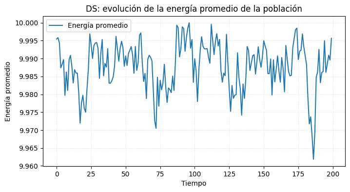

```python
# Gráficas de resultados

# Energía promedio a lo largo del tiempo
plt.figure(figsize=(8, 4))
plt.plot(tiempos, energia_promedio, label="Energía promedio")
plt.xlabel("Tiempo")
plt.ylabel("Energía promedio")
plt.title("DS: evolución de la energía promedio de la población")
plt.grid(True, linestyle=":", alpha=0.4)
plt.legend()
plt.show()
```

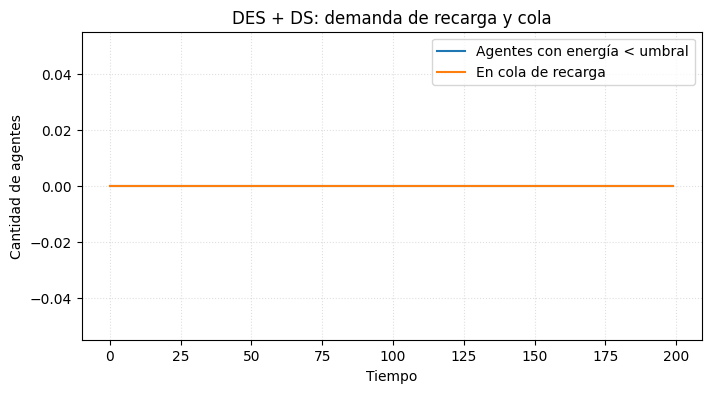

```python
# Agentes bajo umbral y cola de recarga
plt.figure(figsize=(8, 4))
plt.plot(tiempos, agentes_bajo_umbral, label="Agentes con energía < umbral")
plt.plot(tiempos, en_cola_recarga, label="En cola de recarga")
plt.xlabel("Tiempo")
plt.ylabel("Cantidad de agentes")
plt.title("DES + DS: demanda de recarga y cola")
plt.grid(True, linestyle=":", alpha=0.4)
plt.legend()
plt.show()
```

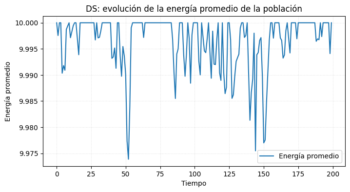

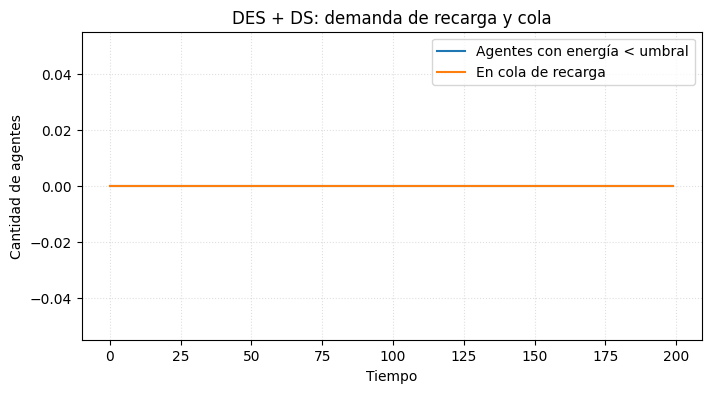

[figure not shown]

[figure not shown]